# Best New Orleans Restaurants for Picky Eaters in the Yelp Open Dataset

Author

Dannette Tucker

Published

November 15, 2026

## Research question

What restaurants in New Orleans are best for a tourist family that includes picky eaters?

Answer in the tables and map below. The tables show the 10 best candidates for picky eaters in each of the 7 ZIP codes containing the most candidates; the restaurants in all 14 ZIPs with at least 10 candidates are plotted on the map below.

**70130**

| Rank | Restaurant | Address | Raw mean | Adjusted score |
| --- | --- | --- | --- | --- |
| 1 | Le Citron Bistro | 1539 Religious St | 3.81 | 0.74 |
| 2 | Breads on Oak Cafe & Bakery | 222 Carondelet St | 4.52 | 0.54 |
| 3 | Paulie Gee’s Crescent City Slice Shop | 726 Julia St | 4.57 | 0.48 |
| 4 | Gyu-Kaku Japanese BBQ | 400 Lafayette St, Ste 101 | 4.39 | 0.47 |
| 5 | House of Blues Restaurant & Bar | 225 Decatur St | 4.13 | 0.44 |
| 6 | Lilly’s Cafe | 1813 Magazine St | 4.35 | 0.35 |
| 7 | Gus’s World Famous Fried Chicken | 308 S Diamond St | 4.59 | 0.34 |
| 8 | Ruby Slipper Cafe | 204 Decatur St | 4.44 | 0.32 |
| 9 | Carmo | 527 Julia St | 4.40 | 0.32 |
| 10 | Majoria’s Commerce Restaurant | 300 Camp St | 4.43 | 0.31 |

**70119**

| Rank | Restaurant | Address | Raw mean | Adjusted score |
| --- | --- | --- | --- | --- |
| 1 | The Fat Falafel | 3141 Ponce De Leon St | 4.73 | 0.82 |
| 2 | Orchid Seafood | 1201 N Broad St | 4.48 | 0.58 |
| 3 | Good Eden Nola Plantmade | 2940 Canal St, Ste A | 4.61 | 0.54 |
| 4 | Addis Nola | 424 S Broad St | 4.75 | 0.53 |
| 5 | Fharmacy Nola | 2540 Banks St | 4.61 | 0.51 |
| 6 | Jaidyn’s Wing Stop/Food For The Soul | 3216 Tulane Ave, Ste A | 4.58 | 0.45 |
| 7 | Sweet Soulfood | 1025 N Broad St | 4.72 | 0.44 |
| 8 | Liberty’s Kitchen | 300 N Broad St | 4.39 | 0.41 |
| 9 | Bub’s Nola | 4413 Banks St | 4.60 | 0.40 |
| 10 | Beaucoup Eats | 2323 Canal St | 3.91 | 0.37 |

**70115**

| Rank | Restaurant | Address | Raw mean | Adjusted score |
| --- | --- | --- | --- | --- |
| 1 | Shawarma on the Go | 3720 Magazine St | 4.69 | 0.61 |
| 2 | Iacovone Kitchen | 5033 Freret St | 4.85 | 0.55 |
| 3 | Raw Republic | 4528 Magazine St | 4.41 | 0.49 |
| 4 | Bearcat Cafe | 2521 Jena St | 4.61 | 0.47 |
| 5 | Atchafalaya Restaurant | 901 Louisiana Ave | 4.42 | 0.32 |
| 6 | NOLA Pizza Co. | 3001 Tchoupitoulas St | 4.46 | 0.30 |
| 7 | The Business Bar | 4525 Freret St, Ste 107 | 4.16 | 0.30 |
| 8 | Red Dog Diner | 3122 Magazine St | 4.50 | 0.30 |
| 9 | LemonShark Poke | 2901 Magazine St | 4.28 | 0.25 |
| 10 | Parran’s Poboys | 4920 Prytania St | 3.73 | 0.25 |

**70118**

| Rank | Restaurant | Address | Raw mean | Adjusted score |
| --- | --- | --- | --- | --- |
| 1 | CIBO | 1114 S Carrolton Ave, Ste A | 4.76 | 0.44 |
| 2 | Breads on Oak Cafe & Bakery | 8640 Oak St | 4.61 | 0.44 |
| 3 | Boucherie | 8115 Jeannette St | 4.29 | 0.41 |
| 4 | LUCA eats | 7329 Cohn St | 4.60 | 0.32 |
| 5 | Max Well - New Orleans | 6101 Magazine St | 4.48 | 0.31 |
| 6 | Empanola | 7321 Freret St | 4.29 | 0.23 |
| 7 | The Camellia Grill | 626 S Carrollton Ave | 4.12 | 0.22 |
| 8 | Raising Cane’s Chicken Fingers | 3235 S Carrollton Ave | 3.12 | 0.09 |
| 9 | Reginelli’s Pizzeria | 5961 Magazine St | 3.80 | 0.07 |
| 10 | Kindred | 7537 Maple St | 4.36 | 0.04 |

**70112**

| Rank | Restaurant | Address | Raw mean | Adjusted score |
| --- | --- | --- | --- | --- |
| 1 | Two Chicks Café - CBD | 920 Gravier St | 4.59 | 0.49 |
| 2 | Reginelli’s Pizzeria | 930 Poydras St, Suite 100 | 3.86 | 0.23 |
| 3 | Vegan Wit A Twist | 514 S Rampart St | 4.35 | 0.20 |
| 4 | Crescent City Pizza Works | 407 Bourbon St | 4.31 | 0.09 |
| 5 | Cleo’s | 940 Canal St | 4.22 | 0.07 |
| 6 | P & G Restaurant & Bar | 345 Baronne St | 4.17 | 0.05 |
| 7 | Powdered Sugar | 800 Iberville St | 3.86 | 0.02 |
| 8 | Deanie’s Seafood | 841 Iberville St | 3.66 | -0.04 |
| 9 | Palm&Pine | 308 N Rampart St | 4.32 | -0.07 |
| 10 | Willie Mae’s At The Market | 234 Loyola Ave | 4.14 | -0.20 |

**70116**

| Rank | Restaurant | Address | Raw mean | Adjusted score |
| --- | --- | --- | --- | --- |
| 1 | Holy Crepes! | 1100 N Peters St, Ste 23 | 4.67 | 0.72 |
| 2 | I-tal Garden | 810 N Claiborne Ave | 4.68 | 0.49 |
| 3 | Meals From The Heart Cafe | 1100 N Peters St, Ste 13, Farmers Market Food Court Facing French Market Pl | 4.53 | 0.39 |
| 4 | J’s Creole Wings | 1700 N Claiborne Ave | 4.37 | 0.34 |
| 5 | Café Amelie | 912 Royal St | 4.25 | 0.19 |
| 6 | The New Orleans Vampire Cafe | 801 Royal St | 4.18 | 0.08 |
| 7 | The Organic Banana | 1100 N Peters St | 4.16 | 0.08 |
| 8 | Flambo Burgers & Bar | 1101 Decatur St | 3.60 | 0.07 |
| 9 | Mona Lisa Restaurant | 1212 Royal St | 4.07 | 0.06 |
| 10 | Pat O’Brien’s | 718 St Peter St | 3.94 | -0.01 |

**70124**

| Rank | Restaurant | Address | Raw mean | Adjusted score |
| --- | --- | --- | --- | --- |
| 1 | The Crazy Italian | 206 W Harrison Ave | 4.17 | 0.36 |
| 2 | Two Tony’s Restaurant | 8536 Pontchartrain Blvd | 4.08 | 0.17 |
| 3 | Francesca by Katie’s | 515 Harrison Ave | 4.25 | 0.15 |
| 4 | Russell’s Marina Grill | 8555 Pontchartrain Blvd | 4.08 | 0.12 |
| 5 | Rosedale | 801 Rosedale Dr | 4.11 | 0.10 |
| 6 | District Donuts Sliders & Brew Lakeview | 527 Harrison Ave | 3.93 | 0.09 |
| 7 | Lakeview Brew Coffee Cafe | 5606 Canal Blvd | 3.95 | 0.06 |
| 8 | Reginelli’s Pizzeria | 874 Harrison Ave | 3.80 | 0.00 |
| 9 | JB’s Fuel Dock | 126 S Roadway St | 4.13 | 0.00 |
| 10 | The Backyard | 244 W Harrison Ave | 3.94 | -0.01 |

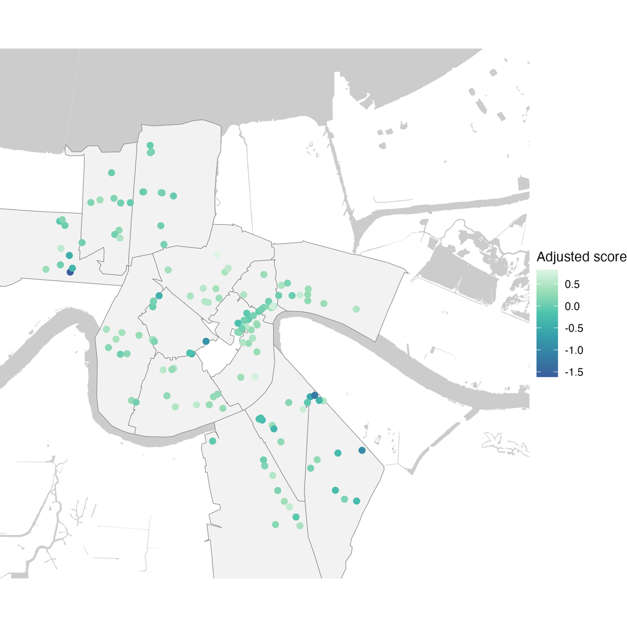

Top 10 restaurants in each ZIP code, colored by adjusted score

## Setup

```r
library(tidyverse)
library(lubridate)
library(sf)
library(tigris)
library(scales)
library(viridis)
library(ggspatial)
library(prettymapr)
library(leaflet)
library(shadowtext)
library(ggrepel)
source("R/config.R")

options(tigris_use_cache = TRUE)

business <- readRDS(business_out)
reviews  <- readRDS(no_text_out) |>
  mutate(date = ymd_hms(date))
# users <- readRDS(user_out)
# reviewer_reviews <- readRDS(reviewer_reviews_out)
```

## Large-data management

The Yelp review file is about 5 GB of newline-delimited JSON, too large to open comfortably in a normal R session.

- **Download and extraction:** I downloaded the Yelp Open Dataset archive from https://business.yelp.com/data/resources/open-dataset/ and extracted it, and the .tar inside, with macOS’s built-in Archive Utility and placed the two JSON files used in this project (`yelp_academic_dataset_business.json` and `yelp_academic_dataset_review.json`) in `data/raw/`.
- **Storage:** the raw JSON files live in `data/raw/`, which is not committed to GitHub. Filtered outputs live in `data/LA/`.
- **Import:** `jsonlite::stream_in()` reads the file in chunks of 100,000 reviews. A handler function filters each chunk to Louisiana restaurants before keeping it, so memory use stays low. Parsing the full file took about 355 seconds. For the reviewers, the handler filtered out friends, which was most of the data. Parsing that file took about 186 seconds.
- **Caching:** the filtered result is saved as an RDS file, a compressed binary format that reads in seconds. Later runs use this filtered data instead of the entire dataset.
- **GitHub limits:** the filtered reviews with text were 131 MB as RDS, above GitHub’s 100 MB file limit. The repository includes a version without the `text` column instead.
- **Problems and fixes:** The closest thing to a problem I experienced was the length of time that the import took, which was about 6 minutes. I did not consider it necessary to try to make it faster.

```r
library(tidyverse)
library(jsonlite)
source("R/config.R")

overwrite <- FALSE   # set TRUE to rebuild the cached files, then set back to FALSE

business_file <- "data/raw/yelp_academic_dataset_business.json"
review_file <- "data/raw/yelp_academic_dataset_review.json"
user_file <- "data/raw/yelp_academic_dataset_user.json"

dir.create(out_dir, recursive = TRUE, showWarnings = FALSE)

# Businesses: small file, parse directly, keep the area only
if (overwrite || !file.exists(business_out)) {
  business <- jsonlite::stream_in(file(business_file), verbose = FALSE) |>
    select( # on changing select, set overwrite to TRUE
      business_id, name, address, city, state, postal_code,
      latitude, longitude, stars, review_count, categories,
      is_open, attributes, hours
    ) |>
    # on changing filters, set overwrite to TRUE
    filter(state %in% area_state, str_detect(categories, "Restaurants"))

  saveRDS(business, business_out)
}

# Reviews: stream in chunks, keep only the area's businesses
if (overwrite || !file.exists(review_out)) {
  area_ids <- readRDS(business_out)$business_id
  chunks <- list()

  print(system.time(
    jsonlite::stream_in(
      file(review_file),
      pagesize = 100000,
      verbose = FALSE,
      handler = function(df) {
        chunks[[length(chunks) + 1]] <<- df |>
          filter(business_id %in% area_ids) |>
          # on changing select, set overwrite to TRUE
          select(business_id, user_id, stars, date, text, useful, funny, cool)
      })))

  saveRDS(bind_rows(chunks), review_out)
}

if (overwrite || !file.exists(no_text_out)) {
  saveRDS(select(readRDS(review_out), -text), no_text_out)
}

# Reviewers
if (overwrite || !file.exists(user_out)) {
  reviewer_ids <- unique(readRDS(no_text_out)$user_id)
  chunks <- list()

  print(system.time(
    jsonlite::stream_in(
      file(user_file),
      pagesize = 100000,
      verbose = FALSE,
      handler = function(df) {
        chunks[[length(chunks) + 1]] <<- df |>
          filter(user_id %in% reviewer_ids) |>
          # on changing select, set overwrite to TRUE
          select(user_id, review_count, average_stars, yelping_since, useful, funny, cool, fans)
      }
    )
  ))

  saveRDS(bind_rows(chunks), user_out)
}

# All reviews written by the area's reviewers, anywhere in the dataset (no text)
if (overwrite || !file.exists(reviewer_reviews_out)) {
  reviewer_ids <- unique(readRDS(no_text_out)$user_id)
  chunks <- list()

  print(system.time(
    jsonlite::stream_in(
      file(review_file),
      pagesize = 100000,
      verbose = FALSE,
      handler = function(df) {
        chunks[[length(chunks) + 1]] <<- df |>
          filter(user_id %in% reviewer_ids) |>
          # on changing select, set overwrite to TRUE
          select(business_id, user_id, stars, date)
      })))

  saveRDS(bind_rows(chunks), reviewer_reviews_out)
}
```

```r
library(tidyverse)
source("R/config.R")

# Searches the review text for picky-eater phrases and caches the matches.
# Needs data/LA/reviews.rds (the version with text), created by R/import.R .

overwrite <- FALSE   # set TRUE after changing the phrases, then set back to FALSE

if (!file.exists(review_out)) {
  stop(review_out, " not found. Run R/import.R first.")
}

apos <- "['’]?"   # optional straight or curly apostrophe

# One regex per phrase; a review can match several phrases.
# "picky" alone overlaps the first two on purpose, to check how precise it is.
phrases <- c(    # Set overwrite to TRUE after changing phrases, then set back to FALSE
  picky_eater    = "picky eaters?",
  picky_kid      = "picky (kids?|child|children|son|daughter|toddlers?|teens?)",
  picky          = "picky",
  kids_menu      = paste0("(kids?", apos, "s?", apos, "|children", apos, "s) menu"),
  kid_friendly   = "(kid|family)[- ]friendly",
  for_families   = "great for families",
  for_everyone   = "something for everyone",
  accommodate    = "accommodat(e|ed|ing)",
  customize      = "customiz(e|able|ible|ations?)",
  tenders        = "chicken (tenders?|fingers?|strips?|nuggets?)",
  grilled_cheese = "grilled cheese",
  mac_cheese     = "mac (and|&|n|n'|'n') cheese|macaroni and cheese"
)

if (overwrite || !file.exists(picky_out)) {
  reviews <- readRDS(review_out)

  matches <- imap(phrases, \(pattern, name) {
    rx   <- regex(paste0("\\b(", pattern, ")\\b"), ignore_case = TRUE)
    hits <- reviews |> filter(str_detect(text, rx))
    pos  <- str_locate(hits$text, rx)   # first match in each review

    hits |>
      mutate(
        phrase  = name,
        snippet = str_sub(text, pmax(1, pos[, "start"] - 100), pos[, "end"] + 100)
      ) |>
      select(business_id, user_id, date, stars, phrase, snippet)
  }) |>
    list_rbind()

  saveRDS(matches, picky_out)
}

# Sample for the precision check. Label the "relevant" column by hand (y/n).
# Not overwritten on rerun, so labels are safe; delete the file to resample.
picky_sample <- file.path(out_dir, "picky_sample.csv")

if (!file.exists(picky_sample)) {
  set.seed(1)
  readRDS(picky_out) |>
    group_by(phrase) |>
    slice_sample(n = 50) |>
    ungroup() |>
    mutate(relevant = NA) |>
    write_csv(picky_sample)
}

# Quick check: matches and restaurants per phrase
readRDS(picky_out) |>
  group_by(phrase) |>
  summarise(reviews = n(), restaurants = n_distinct(business_id)) |>
  arrange(desc(reviews))
```

## Data overview

The import keeps every Louisiana business in Yelp’s “Restaurants” category and all of their reviews, summarized in the table. I included the whole state for several reasons: to include the entire study area (since parishes are not included in the dataset); possibly more reviews per reviewer for the normalization; so that it will be easier to rerun the project for another area.

```r
tibble(
  Measure = c("Louisiana restaurants", "Reviews of those restaurants",
              "Distinct reviewers", "Earliest review", "Latest review"),
  Value = c(comma(nrow(business)), comma(nrow(reviews)),
            comma(n_distinct(reviews$user_id)),
            format(min(reviews$date), "%B %Y"), format(max(reviews$date), "%B %Y"))
) |>
  knitr::kable(align = c("l", "r"))
```

| Measure | Value |
| --- | --- |
| Louisiana restaurants | 3,640 |
| Reviews of those restaurants | 558,340 |
| Distinct reviewers | 221,333 |
| Earliest review | March 2005 |
| Latest review | January 2022 |

## Study area

The study area is the New Orleans tourist core and surrounding area, so I select restaurants within about 6 miles of the main tourist district of New Orleans, the French Quarter. The study area then includes New Orleans City Park, which contains the New Orleans Museum of Art and the Louisiana Children’s Museum, both places that families are likely to visit.

I determined the study area by locating the French Quarter on Google Earth and using the measuring tool to visualize a radius of about 5-6 miles or 8000-10000 meters. That distance was based on the maximum amount of time my own family is typically willing to drive in a metro area in order to find a restaurant that works for all of us (about 30 minutes). I confirmed the approximate travel time by getting directions to ten or so locations around the study area in Google Maps with a “leave at” time of 4:30 pm from Jackson Square in the heart of the French Quarter.

The map below shows the study area. Zoom or drag to explore. Hover over the dots on the map to see the restaurants.

```r
# For NOLA, the center is Jackson Square, the heart of the French Quarter
center   <- st_sfc(st_point(c(center_lon, center_lat)), crs = 4326)

restaurants <- business |>
  filter(
    !is.na(latitude), !is.na(longitude)
  ) |>
  st_as_sf(coords = c("longitude", "latitude"), crs = 4326, remove = FALSE) |>
  st_filter(center, .predicate = st_is_within_distance, dist = radius_m) |>
  st_drop_geometry()

tibble(
  Measure = c("Louisiana restaurants", "Study area restaurants"),
  Count = c(nrow(business), nrow(restaurants))
) |>
  knitr::kable(format.args = list(big.mark = ","))
```

| Measure | Count |
| --- | --- |
| Louisiana restaurants | 3,640 |
| Study area restaurants | 2,728 |

```r
center_xy <- st_coordinates(center)

leaflet() |>
  addTiles() |>
  addCircles(lng = center_xy[, "X"], lat = center_xy[, "Y"], radius = radius_m,
             fill = FALSE, color = "red", weight = 2) |>
  addCircleMarkers(data = restaurants, lng = ~longitude, lat = ~latitude,
                   radius = 2, stroke = FALSE, fillOpacity = 0.5,
                   label = ~name) |>
  addMarkers(lng = center_xy[, "X"], lat = center_xy[, "Y"], label = "Jackson Square")
```

[interactive chart not shown]

I included only restaurants with at least 30 reviews, because averages from a handful of reviews are unreliable.

```r
all_reviewer_summary <- reviews |>
  semi_join(restaurants, by = "business_id") |>
  summarize(
    n_reviews  = n(),
    raw_mean   = mean(stars),
    raw_median = median(stars),
    .by = business_id
  ) |>
  filter(n_reviews >= min_biz_reviews)
```

## Picky-eater search

`picky_search.R` pulls restaurant reviews containing phrases likely to indicate that a restaurant is good for picky eaters, collects a 200-character snippet from each review containing each phrase, and exports 50 random snippets per phrase. I manually marked whether each snippet seemed to indicate that the restaurant did work for a picky eater, then used the resulting table to choose phrases that are actually relevant to picky eaters.

I was surprised at how useless most of the phrases turned out to be. Even “picky eater” had far fewer relevant hits than I was expecting. But it does make sense that “picky kid” would be more relevant; I’d expect parents to be more likely to mention in a review the unusual event that a restaurant works for their picky kids than to mention the common one (that it doesn’t). For this reason and because there were not many mentions of key phrases in the data, I added some categories by hand in the category analysis (American (Traditional), Barbeque, Burgers, Diners, Fast Food, Italian, Mexican, Pizza, and Southern). I also chose not to restrict the search based on the number of reviews a particular Yelp user had given. (See Normalized reviewer scores, below.)

Because the research question is about families, and because there were so many unhelpful reviews using the next-most-relevant phrase (“picky eater”), I use a threshold of 0.8 for the precision cutoff, which keeps only the phrase “picky kid” as a guide to find the most likely candidates for a good restaurant.

```r
# Picky-eater signals: review phrases (checked by hand) compared with Yelp attributes.
# Needs: config.R (out_dir, picky_out, min_biz_reviews), business, restaurants, reviews.

picky <- readRDS(picky_out)

# 1. Precision of each phrase, from the hand-labeled sample
picky_sample <- read_csv(file.path(out_dir, "picky_sample.csv"), show_col_types = FALSE) |>
  mutate(relevant = str_to_lower(str_trim(relevant)))   # "Y " and "y" count the same

precision <- picky_sample |>
  group_by(phrase) |>
  summarize(
    checked    = sum(!is.na(relevant)),
    n_relevant = sum(relevant == "y", na.rm = TRUE),
    precision  = n_relevant / checked
  ) |>
  left_join(count(picky, phrase, name = "total_matches"), by = "phrase") |>
  arrange(desc(precision))

precision |>
  mutate(precision = percent(precision, accuracy = 1)) |>
  knitr::kable(col.names = c("Phrase", "Checked", "Relevant", "Precision", "Total matches"),
               align = c("l", "r", "r", "r", "r"))
```

| Phrase | Checked | Relevant | Precision | Total matches |
| --- | --- | --- | --- | --- |
| picky_kid | 50 | 44 | 88% | 71 |
| picky_eater | 50 | 35 | 70% | 595 |
| customize | 50 | 19 | 38% | 482 |
| for_everyone | 50 | 19 | 38% | 772 |
| picky | 50 | 16 | 32% | 2488 |
| kids_menu | 50 | 13 | 26% | 569 |
| for_families | 50 | 7 | 14% | 66 |
| kid_friendly | 50 | 6 | 12% | 1357 |
| accommodate | 50 | 3 | 6% | 8861 |
| tenders | 50 | 2 | 4% | 2209 |
| mac_cheese | 50 | 1 | 2% | 10771 |
| grilled_cheese | 50 | 0 | 0% | 1895 |

```r
precision_cutoff <- 0.8
keep_phrases <- precision |> filter(precision >= precision_cutoff) |> pull(phrase)

# 2. Yelp attributes for study-area restaurants
clean_attr <- function(x) {
  x <- str_remove_all(x, "^u?'|'$")   # u'casual' and 'casual' both become casual
  na_if(x, "None")
}

attrs <- business |>
  semi_join(restaurants, by = "business_id") |>
  select(business_id, attributes) |>
  unpack(attributes) |>
  mutate(
    across(-business_id, clean_attr),
    gfm_known      = str_detect(GoodForMeal, "True"),   # all False is treated as unknown
    good_breakfast = if_else(gfm_known, str_detect(GoodForMeal, "'(breakfast|brunch)': True"), NA),
    good_lunch     = if_else(gfm_known, str_detect(GoodForMeal, "'lunch': True"), NA),
    good_dinner    = if_else(gfm_known, str_detect(GoodForMeal, "'dinner': True"), NA)
  )

# GoodForMeal: TRUE = at least one meal flagged, FALSE = all False, NA = missing
# count(attrs, gfm_known)

# 3. Picky-mention rate per restaurant
picky_biz <- picky |>
  filter(phrase %in% keep_phrases) |>
  distinct(business_id, user_id, date) |>   # a review matching several phrases counts once
  count(business_id, name = "picky_reviews")

picky_rate <- all_reviewer_summary |>
  select(business_id, n_reviews) |>
  left_join(picky_biz, by = "business_id") |>
  mutate(
    picky_reviews = replace_na(picky_reviews, 0L),
    picky_rate    = picky_reviews / n_reviews
  ) |>
  left_join(attrs, by = "business_id")

# 4. Compare the rate with the attributes
check_attrs <- c("GoodForKids", "RestaurantsGoodForGroups", "NoiseLevel", "RestaurantsPriceRange2")

picky_rate |>
  select(picky_reviews, picky_rate, all_of(check_attrs)) |>
  pivot_longer(all_of(check_attrs), names_to = "attribute", values_to = "value") |>
  group_by(attribute, value) |>
  summarize(
    restaurants = n(),
    share_any   = mean(picky_reviews > 0),
    mean_rate   = mean(picky_rate),
    .groups = "drop"
  ) |>
  mutate(across(c(share_any, mean_rate), \(x) percent(x, accuracy = 0.01))) |>
  knitr::kable(col.names = c("Attribute", "Value", "Restaurants",
                             "Share with any mention", "Mean mention rate"),
               align = c("l", "l", "r", "r", "r"))
```

| Attribute | Value | Restaurants | Share with any mention | Mean mention rate |
| --- | --- | --- | --- | --- |
| GoodForKids | False | 380 | 1.58% | 0.00% |
| GoodForKids | True | 1099 | 4.28% | 0.02% |
| GoodForKids | NA | 215 | 0.93% | 0.02% |
| NoiseLevel | average | 1152 | 3.99% | 0.01% |
| NoiseLevel | loud | 101 | 1.98% | 0.00% |
| NoiseLevel | quiet | 193 | 2.59% | 0.02% |
| NoiseLevel | very_loud | 19 | 0.00% | 0.00% |
| NoiseLevel | NA | 229 | 0.87% | 0.02% |
| RestaurantsGoodForGroups | False | 135 | 4.44% | 0.03% |
| RestaurantsGoodForGroups | True | 1395 | 3.37% | 0.01% |
| RestaurantsGoodForGroups | NA | 164 | 1.22% | 0.03% |
| RestaurantsPriceRange2 | 1 | 387 | 0.26% | 0.00% |
| RestaurantsPriceRange2 | 2 | 1072 | 4.57% | 0.02% |
| RestaurantsPriceRange2 | 3 | 127 | 2.36% | 0.00% |
| RestaurantsPriceRange2 | 4 | 7 | 0.00% | 0.00% |
| RestaurantsPriceRange2 | NA | 101 | 1.98% | 0.04% |

## Restaurant categories

```r
rest_cats <- restaurants |>
  select(business_id, categories) |>
  separate_longer_delim(categories, delim = ", ") |>
  rename(category = categories) |>
  mutate(category = str_squish(category))

# Capitalization check - maintain capitalization for plots and tables.
# stop if any category appears with different capitalization
stopifnot(
  rest_cats |>
    distinct(category) |>
    count(lower = str_to_lower(category)) |>
    filter(n > 1) |>
    nrow() == 0
)

# overall rate of picky eater reviews. Initial threshold for choosing categories.
overall_rate <- sum(picky_rate$picky_reviews) / sum(picky_rate$n_reviews)
# manual override of the threshold, to reduce the number of categories:
picky_mention_cutoff <- 0.2 / 1000

# use that threshold to choose categories for picky eaters:
cat_signals <- picky_rate |>
  inner_join(rest_cats, by = "business_id") |>
  group_by(category) |>
  summarize(
    restaurants  = n(),
    mentions     = sum(picky_reviews),
    mention_rate = sum(picky_reviews) / sum(n_reviews)
  ) |>
  filter(restaurants >= 20)

# explicitly excluded categories
excluded_cats <- c("Sports Bars")

# categories chosen by the mention-rate rule
rule_cats <- cat_signals |>
  filter(mention_rate > picky_mention_cutoff, mentions >= 3,
         !category %in% excluded_cats) |>
  pull(category)

# add categories generally expected to be good for picky eaters
added_cats <- c("American (Traditional)", "Barbeque", "Burgers", "Diners",
                "Fast Food", "Italian", "Mexican", "Pizza", "Southern")

# candidate categories
candidate_cats <- union(rule_cats, added_cats)

# restaurant-level filters (independent of category)
# restaurants marked not good for kids; missing values are kept
not_for_kids <- attrs |> filter(GoodForKids == "False") |> pull(business_id)

# eligible restaurants are operational and not marked as not good for kids.
# they also must have enough reviews
eligible <- restaurants |>
  filter(is_open == 1, !business_id %in% not_for_kids) |>
  semi_join(all_reviewer_summary, by = "business_id")

# co-occurrence among candidate categories, eligible restaurants only
cand  <- rest_cats |>
  filter(category %in% candidate_cats) |>
  semi_join(eligible, by = "business_id")
sizes <- count(cand, category, name = "n_cat")

# candidate categories' Jaccard values
overlap <- cand |>
  inner_join(cand, by = "business_id", relationship = "many-to-many") |>
  count(cat_a = category.x, cat_b = category.y, name = "shared") |>
  left_join(rename(sizes, cat_a = category, n_a = n_cat), by = "cat_a") |>
  left_join(rename(sizes, cat_b = category, n_b = n_cat), by = "cat_b") |>
  mutate(jaccard = shared / (n_a + n_b - shared))

# keep candidates related to at least one other candidate
selected_cats <- overlap |>
  filter(cat_a != cat_b) |>
  group_by(cat_a) |>
  summarize(max_jaccard = max(jaccard)) |>
  filter(max_jaccard >= 0.05) |>
  pull(cat_a)

# exclusions table with reasons
exclusions <- tribble(
  ~business_id,                ~name,                         ~reason,
  "YIWBvaCSeIKLcXAQWkvz9w",   "Bonafried",                    "Food truck with no address",
  "_C7QiQQc47AOEv4PE3Kong",   "Commander's Palace",           "Formal dining with dress code",
  "UmjITdXHhEF46ho6IhaGQg",   "Dave & Buster's",              "Arcade and sports bar",
  "nGYXglmKHgUcovuTHIg6_A",   "Food Drunk Food Truck",        "Food truck with no address",
  "nk96iwJV1_p2HECYQW1ysA",   "French Quarter Phantoms",      "Tour company, not a restaurant",
  "yvh5qUSAbjMnvYy_HrATdQ",   "Hooters",                      "Adult-oriented bar",
  "OyF6c2he3Aej9itlH8oz-A",   "Jewel of the South",           "Cocktail bar; not good for picky eaters",
  "9kv9JpLhzkN3UeWZDrsmEA",   "The Country Club",             "Adult-oriented venue and bar",
  "girDKh9waA2VA81x4h02Lw",   "Main Squeeze Juice Co.",       "Juice bar",
  "PPow3qO48buSNaEkQ_us_w",   "Nola Mia Gelato Cafe",         "Dessert place",
  "2Sgt5ekJ7F785czScIZEYg",   "Piccola Gelateria",            "Dessert place",
  "aWrfoWJFBVQcgMVaD6Bvyw",   "Stop Jockin Snoballs",         "Dessert place"
)

# candidate restaurants
picky_group <- eligible |>
  semi_join(filter(rest_cats, category %in% selected_cats), by = "business_id") |>
  anti_join(exclusions, by = "business_id")

dropped_cats <- setdiff(candidate_cats, selected_cats)
dropped_text <- if (length(dropped_cats) > 0) str_flatten_comma(dropped_cats) else "none"
```

I kept businesses with “Restaurants” in their category list, trimmed extra whitespace from category names, and ensured all categories have consistent capitalization. I then chose categories in three steps:

1. I selected categories with at least 20 restaurants with 30 or more reviews, at least 3 mentions of “picky kid” in the reviews, and more than 0.2 such reviews per 1000. I chose the last cutoff to reduce the number of categories to a manageable level. Additionally, because Sports Bars are generally not good for families, I excluded that category.
2. Some types of restaurants are often expected to be good for picky eaters, and therefore would be unlikely to be mentioned as such in reviews – I would expect the opposite, that such reviews mentioning picky eaters would more likely be complaints. I therefore included American (Traditional), Barbeque, Burgers, Diners, Fast Food, Italian, Mexican, Pizza, Southern categories despite their low mention rate in the analysis.
3. Categories that share many restaurants describe similar places. I kept a candidate if its Jaccard overlap (restaurants in both categories divided by restaurants in either) with at least one other candidate was 0.05 or more.

The final selection is American (Traditional), Barbeque, Burgers, Comfort Food, Diners, Fast Food, Italian, Pizza, Southern, Steakhouses, Vegan. Of these, Comfort Food, Pizza, Southern, Steakhouses, Vegan came from the “picky kid” search.

A restaurant is a candidate if it is open, is not marked by Yelp as not good for kids (restaurants with no value for that attribute are kept), has at least 30 reviews, belongs to at least one of the selected categories, and is not on the exclusion list below. 402 restaurants in the study area meet these criteria.

I removed 12 businesses by hand that matched a selected category but do not fit the question: businesses that are not restaurants, food trucks with no address, bars and adult-oriented venues, formal dining, and places that serve only desserts or juice.

```r
exclusions |>
  select(name, reason) |>
  knitr::kable(col.names = c("Restaurant", "Reason removed"))
```

| Restaurant | Reason removed |
| --- | --- |
| Bonafried | Food truck with no address |
| Commander’s Palace | Formal dining with dress code |
| Dave & Buster’s | Arcade and sports bar |
| Food Drunk Food Truck | Food truck with no address |
| French Quarter Phantoms | Tour company, not a restaurant |
| Hooters | Adult-oriented bar |
| Jewel of the South | Cocktail bar; not good for picky eaters |
| The Country Club | Adult-oriented venue and bar |
| Main Squeeze Juice Co. | Juice bar |
| Nola Mia Gelato Cafe | Dessert place |
| Piccola Gelateria | Dessert place |
| Stop Jockin Snoballs | Dessert place |

The tabs below show each category’s mention rate (selected categories are right of the dashed line or added by judgment), the overlap among candidates (color is the Jaccard value, numbers are shared restaurants, and the diagonal is each category’s size), and the 10 most-overlapping pairs.

**Picky-kid mentions by category**

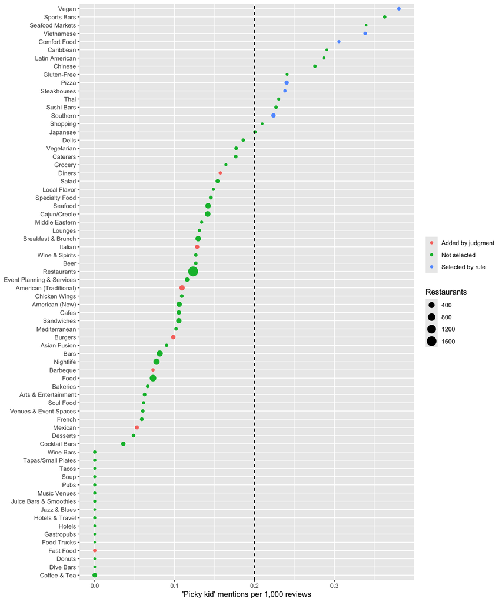

```r
# plot picky-kid mentions by category
cat_signals |>
  mutate(
    category = fct_reorder(category, mention_rate),
    selected = case_when(
      category %in% rule_cats  ~ "Selected by rule",
      category %in% added_cats ~ "Added by judgment",
      .default = "Not selected"
    )
  ) |>
  ggplot(aes(mention_rate * 1000, category, color = selected, size = restaurants)) +
  geom_point() +
  geom_vline(xintercept = picky_mention_cutoff * 1000, linetype = "dashed") +
  labs(x = "'Picky kid' mentions per 1,000 reviews", y = NULL,
       color = NULL, size = "Restaurants")
```

**Category overlap**

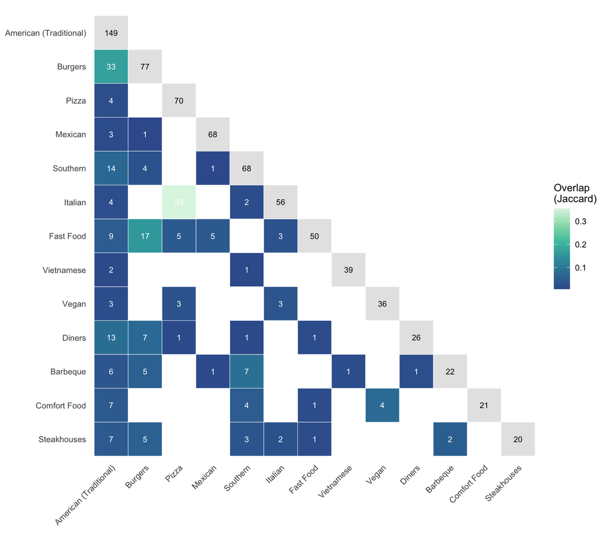

```r
# order the categories
cat_order <- sizes |> arrange(desc(n_cat)) |> pull(category)

# heatmap: color = overlap, label = shared restaurants, diagonal = category size
overlap |>
  mutate(diag    = cat_a == cat_b,
         jaccard = if_else(diag, NA, jaccard),
         cat_a   = factor(cat_a, levels = cat_order),
         cat_b   = factor(cat_b, levels = cat_order)) |>
  filter(as.integer(cat_a) <= as.integer(cat_b)) |>   # lower triangle plus diagonal
  ggplot(aes(cat_a, cat_b, fill = jaccard)) +
  geom_tile(color = "white") +
  geom_text(aes(label = shared, color = diag), size = 3) +
  scale_color_manual(values = c(`TRUE` = "black", `FALSE` = "white"), guide = "none") +
  scale_fill_viridis_c(option = "mako", begin = 0.4, na.value = "grey90") +
  coord_fixed() +
  scale_y_discrete(limits = rev) +
  labs(x = NULL, y = NULL, fill = "Overlap\n(Jaccard)") +
  theme_minimal() +
  theme(axis.text.x = element_text(angle = 45, hjust = 1),
        panel.grid = element_blank())
```

**Most-overlapping pairs**

```r
# Jaccard table: each pair once, most overlap first
overlap |>
  filter(cat_a < cat_b) |>
  arrange(desc(jaccard)) |>
  slice_head(n = 10) |>
  select(cat_a, cat_b, shared, jaccard) |>
  knitr::kable(digits = 2,
               col.names = c("Category", "Category", "Shared restaurants", "Jaccard"))
```

| Category | Category | Shared restaurants | Jaccard |
| --- | --- | --- | --- |
| Italian | Pizza | 33 | 0.35 |
| American (Traditional) | Burgers | 33 | 0.17 |
| Burgers | Fast Food | 17 | 0.15 |
| Barbeque | Southern | 7 | 0.08 |
| American (Traditional) | Diners | 13 | 0.08 |
| Comfort Food | Vegan | 4 | 0.08 |
| Burgers | Diners | 7 | 0.07 |
| American (Traditional) | Southern | 14 | 0.07 |
| Burgers | Steakhouses | 5 | 0.05 |
| Barbeque | Burgers | 5 | 0.05 |

## Geographic systems

The most relevant geographically-related question for a family looking for a meal is how long it will take to get there. Because travel times depend on factors far outside the scope of this project, I use distance as a proxy. I compare two ways to do this: 1. zero in on a particular area and look at restaurants there, and 2. look at restaurants within a certain distance from the center of the study area.

### Boundary systems

I compare three boundary systems: census tracts and ZIP code tabulation areas from the US Census Bureau, and Neighborhood Statistical Areas from the City of New Orleans. Each restaurant point is assigned to a boundary with a spatial join, and I keep only the boundaries that touch the study area. The neighborhood boundaries cover only Orleans Parish, so restaurants elsewhere in the study area, such as Metairie, have no neighborhood. The table below counts them as unmatched.

```r
circle <- st_buffer(center, radius_m)

group_sf <- picky_group |>
  filter(!is.na(latitude)) |>
  st_as_sf(coords = c("longitude", "latitude"), crs = 4326, remove = FALSE)

tracts_sf <- tracts(area_state, cb = TRUE, year = 2022) |>
  st_transform(4326) |>
  select(area_id = starts_with("GEOID")) |>
  st_filter(circle, .predicate = st_intersects)

zips_sf <- zctas(cb = TRUE, starts_with = zcta_prefixes, year = 2020) |>
  st_transform(4326) |>
  select(area_id = starts_with("GEOID")) |>
  st_filter(circle, .predicate = st_intersects)

if (!file.exists(nsa_file)) {
  st_read(nsa_url, quiet = TRUE) |>
    st_transform(4326) |>
    select(area_id = GNOCDC_LAB) |>
    st_write(nsa_file)
}

nsa_sf <- st_read(nsa_file, quiet = TRUE) |>
  st_filter(circle, .predicate = st_intersects)

systems <- list(
  "Census tract" = tracts_sf,
  "ZIP code"     = zips_sf,
  "Neighborhood" = nsa_sf
)

# assign each restaurant to the area that contains it, one table per system
joined <- map(systems, \(polys) st_join(group_sf, polys, join = st_within, left = FALSE))
by_zip <- joined[["ZIP code"]]   # later chunks use by_zip

# restaurant count for every area, including empty ones
all_counts <- map2(systems, joined, \(polys, j) {
  polys |> left_join(j |> st_drop_geometry() |> count(area_id), by = "area_id")
}) |>
  bind_rows(.id = "system") |>
  mutate(n = replace_na(n, 0))

# number of restaurants in 70130
n_70130     <- sum(by_zip$area_id == "70130")
share_70130 <- percent(n_70130 / nrow(by_zip))

# shared size categories and colors for both bar charts
size_breaks <- c(-Inf, 0, 4, 9, 20, 50, Inf)
size_labels <- c("0", "1–4", "5–9", "10–20", "21–50", "51 or more")
size_colors <- c(
  Unmatched = "grey70",
  setNames(mako(length(size_labels), begin = 0.4, direction = -1), size_labels)
)

counts_df <- all_counts |>
  st_drop_geometry() |>
  mutate(size = cut(n, size_breaks, labels = size_labels))

# comparison table
counts_df |>
  group_by(system) |>
  summarize(
    areas      = n(),
    areas_with = sum(n > 0),
    median_n   = median(n[n > 0]),
    smallest   = min(n[n > 0]),
    largest    = max(n),
    under_5    = sum(n > 0 & n < 5),
    unmatched  = nrow(group_sf) - sum(n)
  ) |>
  knitr::kable(
    col.names = c(
      "Geographic system", "Areas in system", "Areas with restaurants",
      "Median restaurants per area", "Smallest count", "Largest count",
      "Areas under 5", "Unmatched restaurants"
    ),
    format.args = list(big.mark = ",")
  )
```

| Geographic system | Areas in system | Areas with restaurants | Median restaurants per area | Smallest count | Largest count | Areas under 5 | Unmatched restaurants |
| --- | --- | --- | --- | --- | --- | --- | --- |
| Census tract | 244 | 127 | 2 | 1 | 63 | 108 | 0 |
| Neighborhood | 69 | 47 | 4 | 1 | 64 | 27 | 87 |
| ZIP code | 31 | 25 | 10 | 1 | 83 | 6 | 0 |

```r
# choropleth
bb1 <- st_bbox(st_buffer(circle, 1500))

roads_sf <- map(parishes, \(p) roads(area_state, p, year = 2022)) |>
  bind_rows() |>
#  filter(MTFCC %in% c("S1100", "S1200")) |>
  st_transform(4326) |>
  st_crop(bb1)

water_sf <- map(parishes, \(p) area_water(area_state, p, year = 2022)) |>
  bind_rows() |>
  st_transform(4326) |>
  st_crop(bb1)

boundary_map <- function(sys, label_ids = NULL) {
  counts <- filter(all_counts, system == sys)
  ggplot(counts) +
    geom_sf(data = water_sf, fill = "grey80", color = NA) +
    geom_sf(data = roads_sf, color = "grey80", linewidth = 0.1) +
    geom_sf(aes(fill = n), alpha = 0.6, color = "white", linewidth = 0.1) +
    geom_sf(data = circle, fill = NA, color = "red") +
    (if (!is.null(label_ids)) ggrepel::geom_text_repel(
      data = filter(counts, area_id %in% label_ids),
      aes(label = area_id, geometry = geometry),
      stat = "sf_coordinates",
      size = 4.5, color = "white", bg.color = "black", bg.r = 0.15,
      max.overlaps = Inf, min.segment.length = 0
    )) +
    coord_sf(xlim = bb1[c("xmin", "xmax")], ylim = bb1[c("ymin", "ymax")], expand = FALSE) +
    scale_fill_viridis_c(option = "mako", begin = 0.4,
                         limits = c(0, max(all_counts$n))) +
    labs(fill = "Restaurants",
         caption = "Roads and water: US Census Bureau TIGER/Line") +
    theme_void()
}
```

The maps below show the system boundaries as white lines, with the study area outlined in red. The first tab shows the census tracts; the second shows neighborhoods, including that they do not cover the entire study area; the third shows the 14 ZIP codes that have at least 10 restaurants that meet the study criteria.

**Census tracts**

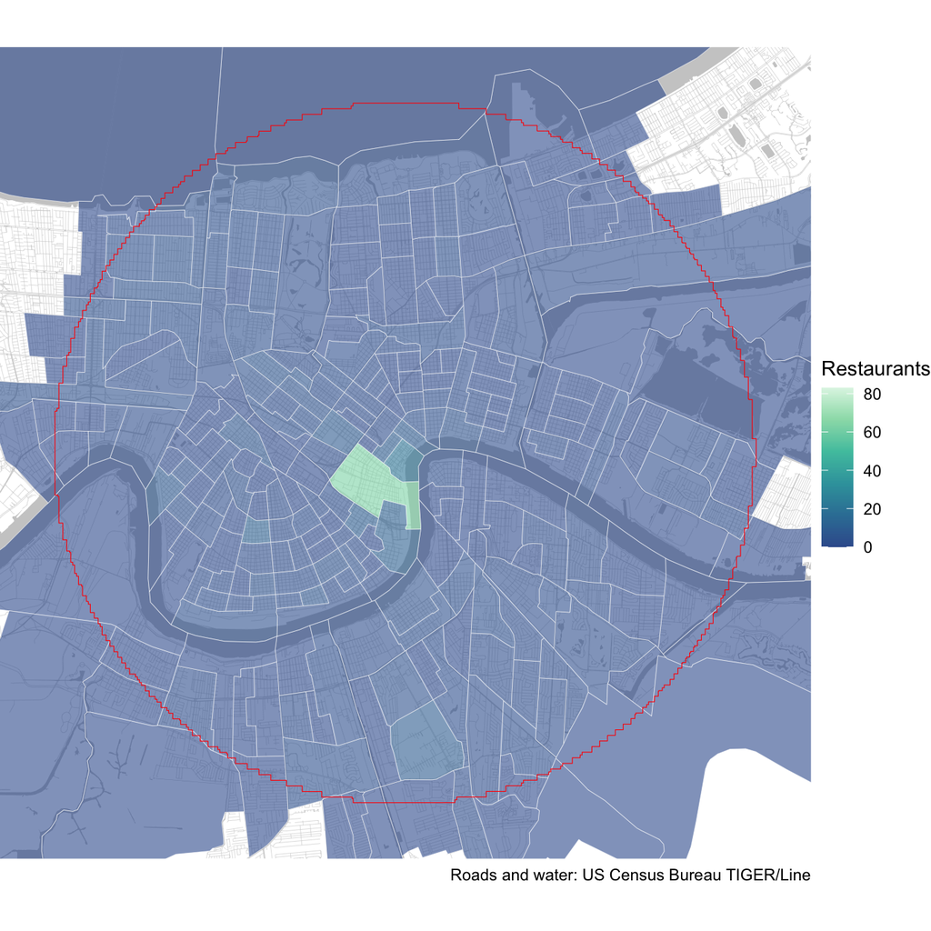

```r
boundary_map("Census tract")
```

**Neighborhoods**

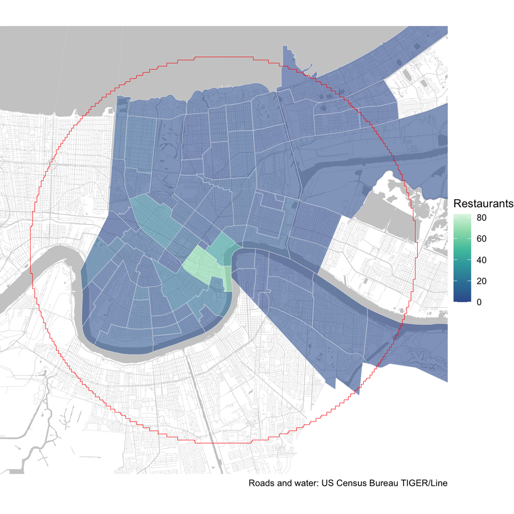

```r
boundary_map("Neighborhood")
```

**ZIP codes**

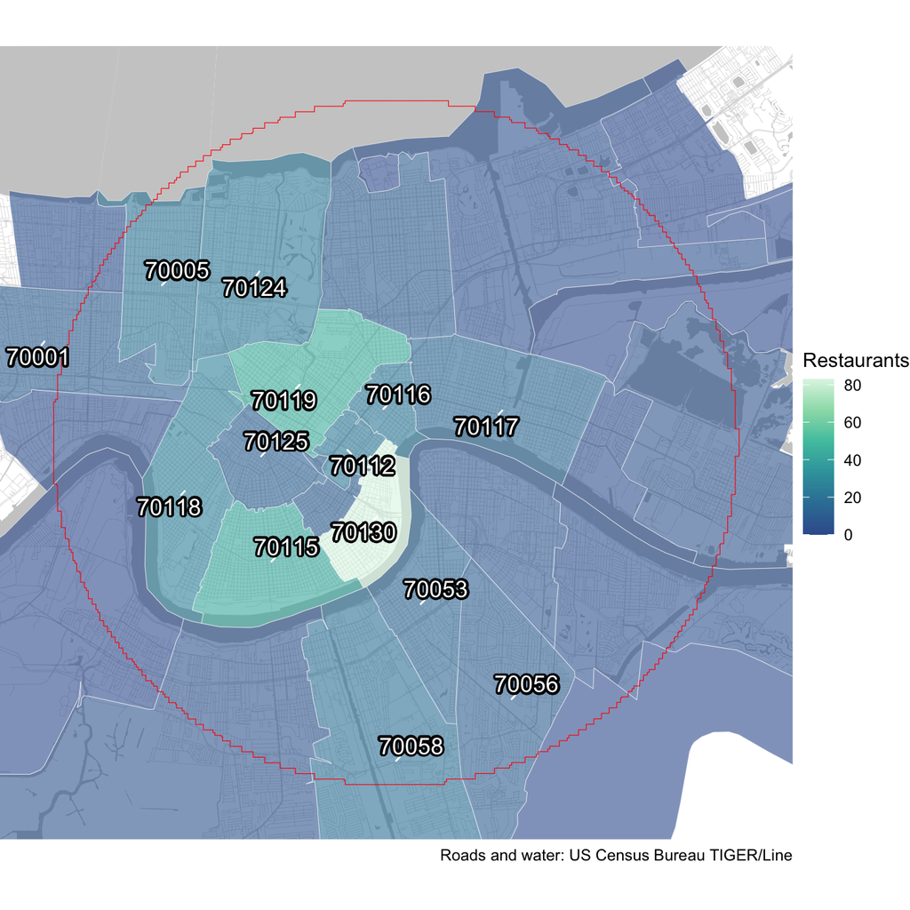

```r
boundary_map("ZIP code", label_ids = c("70001", "70005", "70053", "70056", "70058", "70112",
                                       "70115", "70116", "70117", "70118", "70119", "70124",
                                       "70125", "70130"))
```

These two charts show the differences between the three systems. The first tab shows the number of areas per system; observe the enormous number of census tracts compared to neighborhoods or ZIP codes, and that most of them hold fewer than 10 restaurants each.

The second tab shows, per system, how many restaurants fall into areas of each size. Also note the number of restaurants not located in any New Orleans neighborhood.

If a tourist family picks an area by ZIP code, they’re likely to have many more choices than if they were to look by census tract or neighborhood. The trade-off is that ZIP codes are generally larger areas, so some choices will be farther away.

**Areas by size**

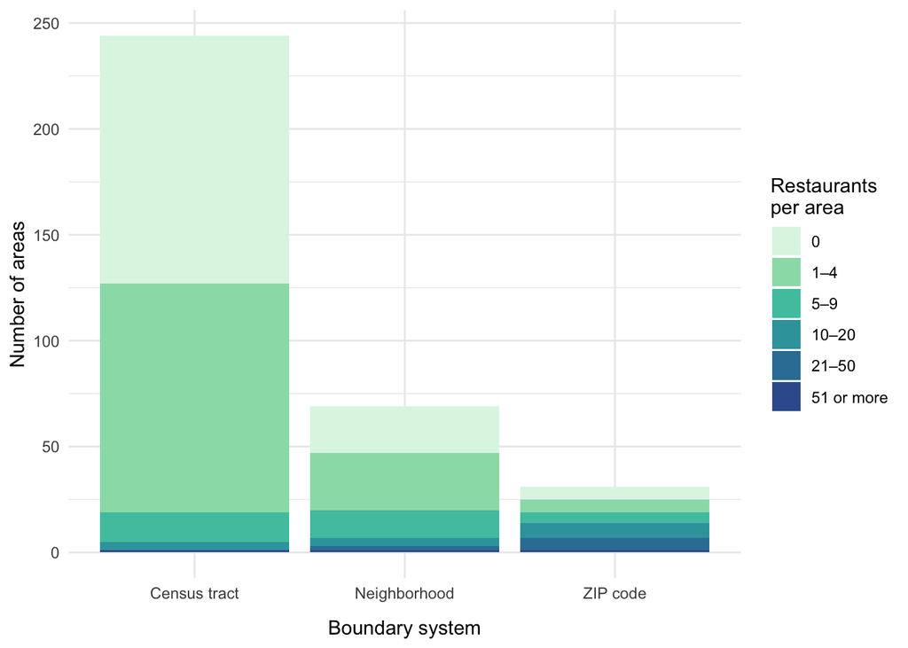

```r
counts_df |>
  count(system, size, name = "areas") |>
  ggplot(aes(system, areas, fill = size)) +
  geom_col() +
  scale_fill_manual(values = size_colors) +
  labs(x = "Boundary system", y = "Number of areas", fill = "Restaurants\nper area") +
  theme_minimal() +
  theme(axis.title.x = element_text(margin = margin(t = 10)))
```

**Restaurants by area size**

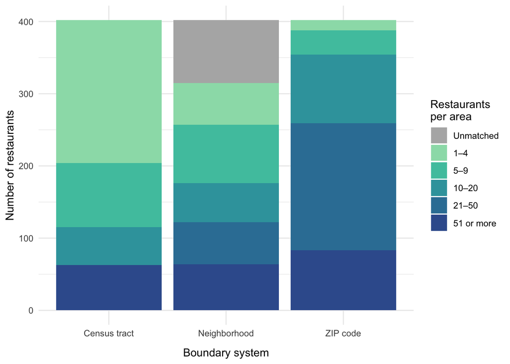

```r
counts_df |>
  filter(n > 0) |>
  group_by(system, size) |>
  summarize(restaurants = sum(n), .groups = "drop") |>
  bind_rows(
    counts_df |>
      group_by(system) |>
      summarize(size = "Unmatched", restaurants = nrow(group_sf) - sum(n))
  ) |>
  mutate(size = factor(size, levels = c("Unmatched", size_labels))) |>
  ggplot(aes(system, restaurants, fill = size)) +
  geom_col() +
  scale_fill_manual(values = size_colors) +
  labs(x = "Boundary system", y = "Number of restaurants", fill = "Restaurants\nper area") +
  theme_minimal() +
  theme(axis.title.x = element_text(margin = margin(t = 10)))
```

### Localized areas vs concentric rings

The boxplot shows how much distance each ZIP mixes together; the ring density plot shows how restaurants thin out with distance. ZIPs are recognizable to a reader, even if they don’t know exactly what area each one covers. Rings measure distance consistently, but only around a certain point.

```r
# one row per restaurant, with distance from Jackson Square in km
rest_dist <- by_zip |>
  mutate(dist_km = as.numeric(st_distance(geometry, center)) / 1000) |>
  st_drop_geometry()

zip_dist <- rest_dist |>
  group_by(area_id) |>
  summarize(n = n(), median_dist_km = median(dist_km))
```

**Spread of distances**

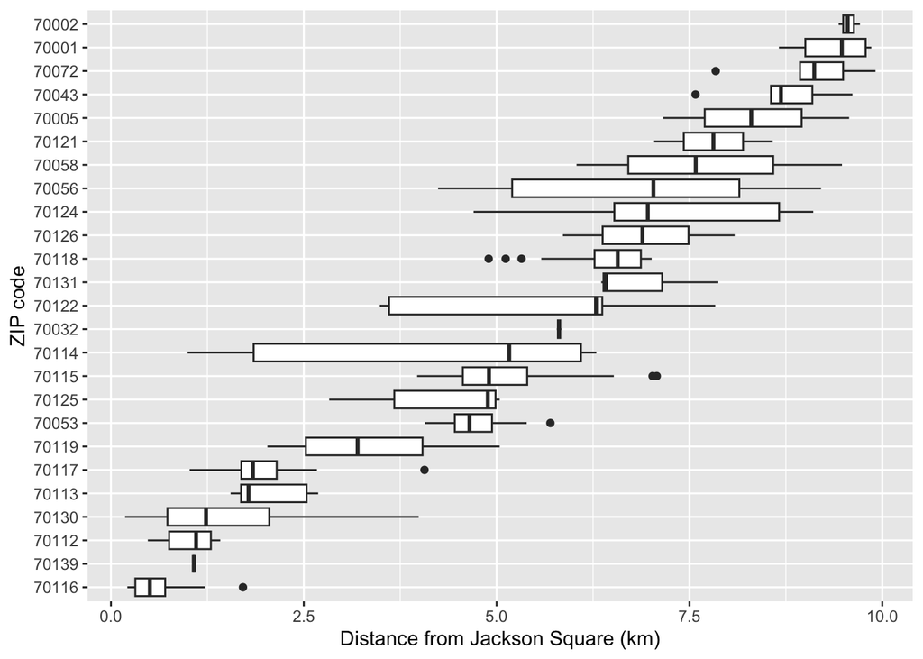

```r
# Spread of distances within each ZIP, ordered by median
rest_dist |>
  mutate(area_id = fct_reorder(area_id, dist_km, .fun = median)) |>
  ggplot(aes(dist_km, area_id)) +
  geom_boxplot() +
  labs(x = "Distance from Jackson Square (km)", y = "ZIP code")
```

**Median distance and restaurant count**

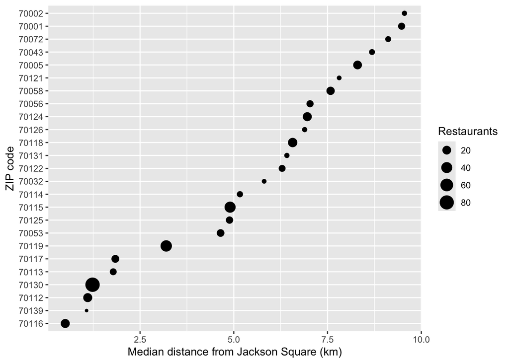

```r
zip_dist |>
  mutate(area_id = fct_reorder(area_id, median_dist_km)) |>
  ggplot(aes(median_dist_km, area_id, size = n)) +
  geom_point() +
  labs(x = "Median distance from Jackson Square (km)",
       y = "ZIP code", size = "Restaurants")
```

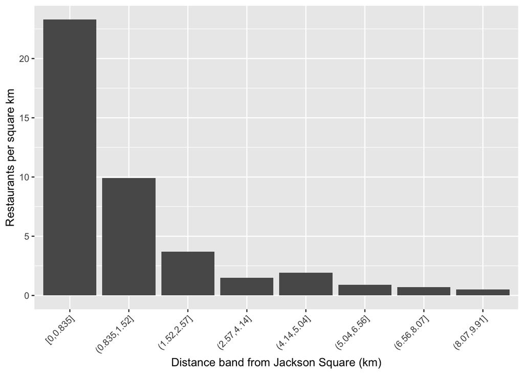

```r
n_rings <- 8

# ring boundaries: quantiles of distance, so each ring holds about the same number of restaurants
breaks <- quantile(rest_dist$dist_km, probs = seq(0, 1, length.out = n_rings + 1))
breaks[1] <- 0   # the innermost ring starts at the center

ring_summary <- rest_dist |>
  mutate(ring = cut(dist_km, breaks, include.lowest = TRUE)) |>
  count(ring) |>
  mutate(r_in = head(breaks, -1),
         r_out = tail(breaks, -1),
         area_km2 = pi * (r_out^2 - r_in^2),
         density = n / area_km2)

ggplot(ring_summary, aes(ring, density)) +
  geom_col() +
  labs(x = "Distance band from Jackson Square (km)",
       y = "Restaurants per square km") +
  theme(axis.text.x = element_text(angle = 45, hjust = 1))
```

```r
# number of zip codes with at least 10 restaurants in the selected category group
n_areas <- by_zip |> st_drop_geometry() |> count(area_id) |> filter(n >= 10) |> nrow()
```